# RExercise#4_Salvador

Crizalin Wilma Salvador

2026-11-10

### PART A - Creating Vectors and List

Question 1: A factory has a census of its workers. There are 50 workers in total. The following list shows their ages: `34, 28, 22, 36, 27, 18, 52, 39, 42, 29, 35, 31, 27, 22, 37, 34, 19, 20, 57, 49, 50, 37, 46, 25, 17, 37, 43, 53, 41, 51, 35, 24,33, 41, 53, 40, 18, 44, 38, 41, 48, 27, 39, 19, 30, 61, 54, 58, 26, 18.

1. Create a vector for the worker’s age.

```r
# Store the ages of the 50 factory workers in a vector
ages <- c(34, 28, 22, 36, 27, 18, 52, 39, 42, 29,
          35, 31, 27, 22, 37, 34, 19, 20, 57, 49,
          50, 37, 46, 25, 17, 37, 43, 53, 41, 51,
          35, 24, 33, 41, 53, 40, 18, 44, 38, 41,
          48, 27, 39, 19, 30, 61, 54, 58, 26, 18)

# Verify total count
length(ages)
```

```
## [1] 50
```

```r
# Five-number summary (Min, 1st Qu, Median, Mean, 3rd Qu, Max)
summary(ages)
```

```
##    Min. 1st Qu.  Median    Mean 3rd Qu.    Max.
##   17.00   27.00   36.50   36.10   43.75   61.00
```

```r
# Additional statistical measurements
mean_age   <- mean(ages)
median_age <- median(ages)
sd_age     <- sd(ages)
range_age  <- range(ages)

# Print specific results
cat("Mean Age:", mean_age, "\n")
```

```
## Mean Age: 36.1
```

```r
cat("Median Age:", median_age, "\n")
```

```
## Median Age: 36.5
```

```r
cat("Standard Deviation:", sd_age, "\n")
```

```
## Standard Deviation: 12.0936
```

```r
cat("Age Range:", range_age[1], "to", range_age[2], "\n")
```

```
## Age Range: 17 to 61
```

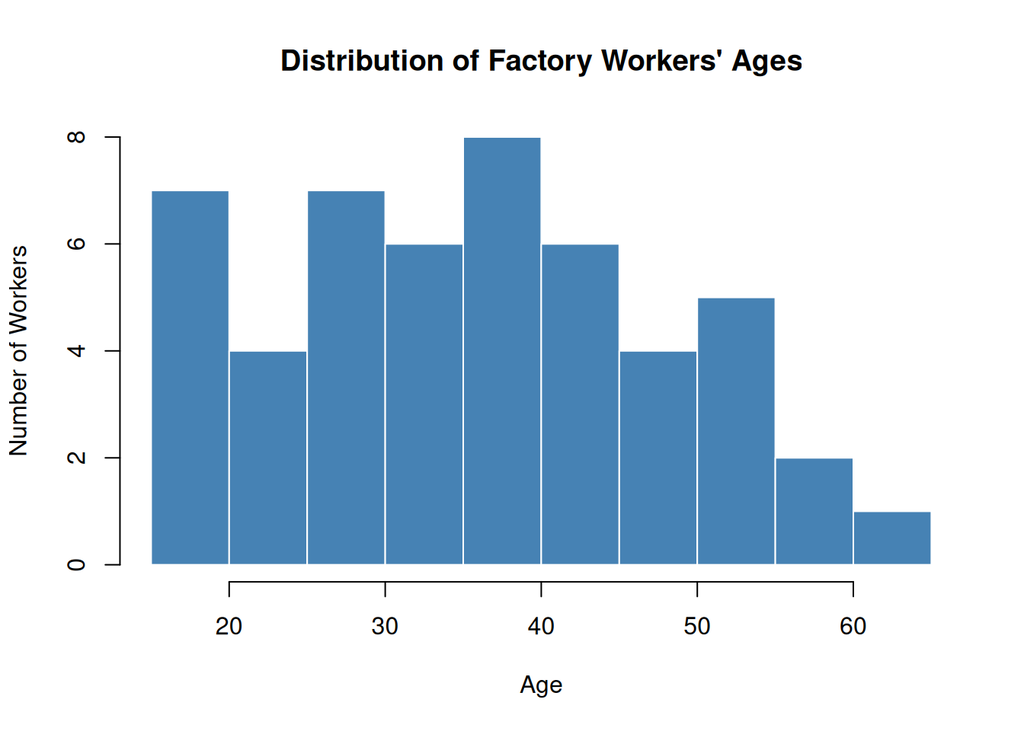

```r
# Optional: Create a visual distribution histogram
hist(ages,
     main = "Distribution of Factory Workers' Ages",
     xlab = "Age",
     ylab = "Number of Workers",
     col = "steelblue",
     border = "white")
```

b. How many data points?

Answer: 50 data points

3. Find the minimum and the maximum value of worker’s age.

```r
# Ages vector
ages <- c(34, 28, 22, 36, 27, 18, 52, 39, 42, 29,
          35, 31, 27, 22, 37, 34, 19, 20, 57, 49,
          50, 37, 46, 25, 17, 37, 43, 53, 41, 51,
          35, 24, 33, 41, 53, 40, 18, 44, 38, 41,
          48, 27, 39, 19, 30, 61, 54, 58, 26, 18)

# Calculate minimum and maximum
min_age <- min(ages)
max_age <- max(ages)

# Print the results
cat("Minimum Age:", min_age, "\n")
```

```
## Minimum Age: 17
```

```r
cat("Maximum Age:", max_age, "\n")
```

```
## Maximum Age: 61
```

4. Access the 13rd to 18th elements and 33th to 35th elements of worker’s Age.

```r
# Ages vector
ages <- c(34, 28, 22, 36, 27, 18, 52, 39, 42, 29,
          35, 31, 27, 22, 37, 34, 19, 20, 57, 49,
          50, 37, 46, 25, 17, 37, 43, 53, 41, 51,
          35, 24, 33, 41, 53, 40, 18, 44, 38, 41,
          48, 27, 39, 19, 30, 61, 54, 58, 26, 18)

# Access 13th to 18th elements
elements_13_to_18 <- ages[13:18]

# Access 33rd to 35th elements
elements_33_to_35 <- ages[33:35]

# Combine both ranges into a single selection
combined_elements <- ages[c(13:18, 33:35)]

# Print results
cat("13th to 18th elements:", elements_13_to_18, "\n")
```

```
## 13th to 18th elements: 27 22 37 34 19 20
```

```r
cat("33rd to 35th elements:", elements_33_to_35, "\n")
```

```
## 33rd to 35th elements: 33 41 53
```

```r
cat("Combined selection:", combined_elements, "\n")
```

```
## Combined selection: 27 22 37 34 19 20 33 41 53
```

```r
# Ages vector
ages <- c(34, 28, 22, 36, 27, 18, 52, 39, 42, 29,
          35, 31, 27, 22, 37, 34, 19, 20, 57, 49,
          50, 37, 46, 25, 17, 37, 43, 53, 41, 51,
          35, 24, 33, 41, 53, 40, 18, 44, 38, 41,
          48, 27, 39, 19, 30, 61, 54, 58, 26, 18)

# Extract specific ranges using index concatenation
subset_ages <- ages[c(13:18, 33:35)]

# Display the extracted vector
subset_ages
```

```
## [1] 27 22 37 34 19 20 33 41 53
```

6. Modify the 4th, 14th, 24th, and 44th elements with value = 0.

```r
# Ages vector
ages <- c(34, 28, 22, 36, 27, 18, 52, 39, 42, 29,
          35, 31, 27, 22, 37, 34, 19, 20, 57, 49,
          50, 37, 46, 25, 17, 37, 43, 53, 41, 51,
          35, 24, 33, 41, 53, 40, 18, 44, 38, 41,
          48, 27, 39, 19, 30, 61, 54, 58, 26, 18)

# Modify the specified indices to 0
ages[c(4, 14, 24, 44)] <- 0

# Display the modified vector
ages
```

```
##  [1] 34 28 22  0 27 18 52 39 42 29 35 31 27  0 37 34 19 20 57 49 50 37 46  0 17
## [26] 37 43 53 41 51 35 24 33 41 53 40 18 44 38 41 48 27 39  0 30 61 54 58 26 18
```

Question 2:

R has actually lots of built-in datasets. For example, the rivers data “gives the lengths (in miles) of 141 “major” rivers in North America, as compiled by the US Geological Survey”. Use data(rivers)